# Au 1er du mois, une partie des variations du nombre de détenus est saisonnière

Comment interpréter correctement les évolutions mensuelles du nombre de personnes détenues ?

Fatma Hammami

**Au 1er décembre 2025, 86 229 personnes sont détenues en France, soit +6,7 % en un an.** D’un mois à l’autre, l’effectif brut varie aussi pour des raisons saisonnières : il est plus élevé au 1er juillet et plus bas au 1er septembre et au 1er janvier. Corriger la série de ces variations change la lecture de certains mois.

## Trois messages clés

1. **Une saisonnalité marquée.** Sur 2021-2025, l’écart entre le mois le plus haut (1er juillet) et le mois le plus bas (1er janvier) atteint en moyenne 1 131 personnes.
2. **Une baisse estivale qui n’en est pas une.** Au 1er août 2025, l’effectif brut recule de 0,9 % ; une fois corrigée, la série est stable (+0,0 %). Au 1er septembre, la hausse brute (+0,2 %) sous-estime la hausse corrigée (+0,5 %).
3. **Un effet « samedis » faible.** Le nombre de samedis du mois précédent n’a pas d’effet significatif sur 2008-2019 (p = 0,78). Sur 2021-2025, il est à la limite de la significativité (64 personnes par samedi supplémentaire, p = 0,08), soit moins de 0,1 % de l’effectif.

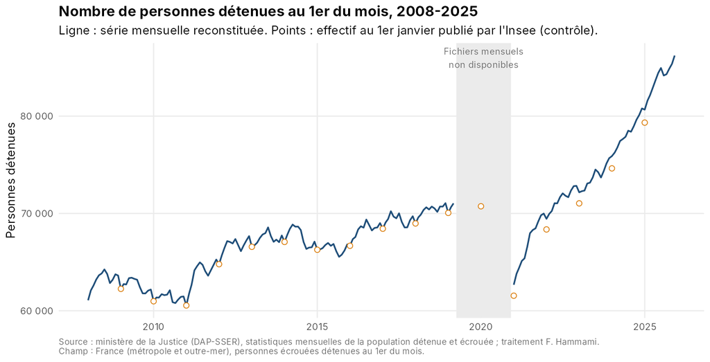

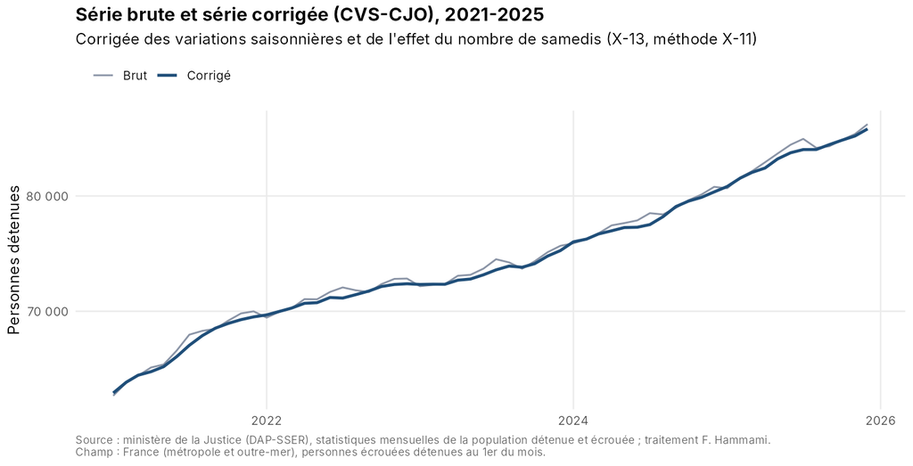

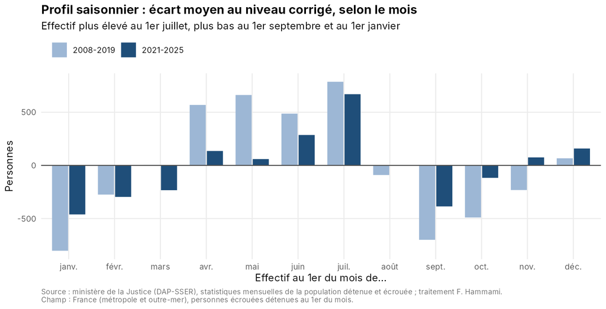

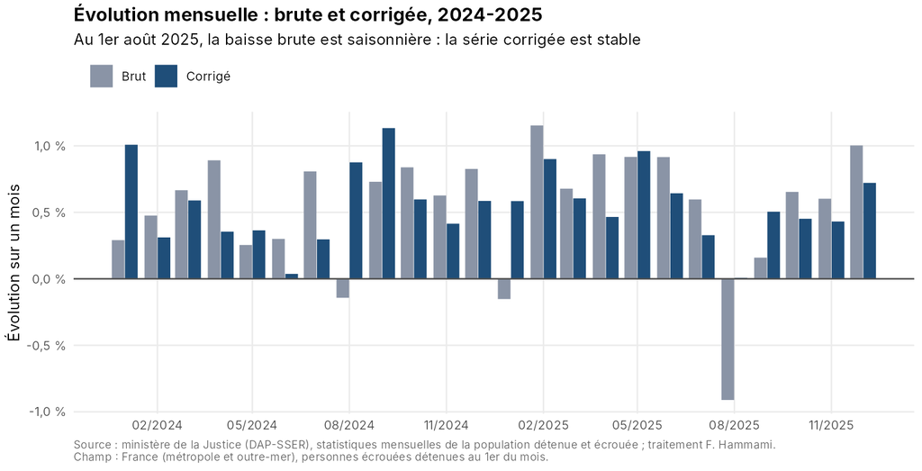

## Effet du nombre de samedis : comparaison des modèles

| Période | Mois | Effet d’un samedi (personnes) | Écart-type | p-value | AICc sans | AICc avec | Modèle retenu |
| --- | --- | --- | --- | --- | --- | --- | --- |
| 2008-2019 | 135 | -7,2 | 25,8 | 0,780 | 1 759,4 | 1 761,5 | sans samedis (CVS) |
| 2021-2025 | 60 | 63,8 | 35,9 | 0,075 | 870,3 | 870,0 | avec samedis (CVS-CJO) |

Le régresseur est conservé uniquement s’il améliore le critère d’information (AICc). Aucune saisonnalité résiduelle n’est détectée dans les séries corrigées (test QS).

## Limites et prolongements

- Compléter la série 2019-2020 en ajoutant les fichiers manquants, puis traiter la crise sanitaire par des points aberrants (changement de niveau).
- Reproduire la désaisonnalisation avec JDemetra+ (packages `rjd3x13` / `rjd3tramoseats`) et comparer.
- Tester l’effet calendaire sur les **flux** (entrées et sorties de détention), où il devrait être plus visible que sur le stock.

*Source : ministère de la Justice (DAP-SSER), statistiques mensuelles de la population détenue et écrouée ; Insee. Traitement : Fatma Hammami. Les définitions officielles ne sont pas modifiées.*